Elif Cansu Yıldız

← All notebooks

July 20, 2022 5 min read

# Playing with HSV Color Space

This notebook covers how to mask color and change to another color using HSV color space which is an alternative color space to RGB where we can modify the colors by just shifting the hue of the image.

[figure not shown]

# Playing with HSV Color Space

```python
import matplotlib.pyplot as pltimport matplotlib.colors as colorsimport numpy as npimport pandas as pdfrom PIL import Imageimport cv2
```

```
rgb_data.shape: (388, 640, 3)
```

[figure not shown]

```python
rgb_data = plt.imread("Data/oldtimer.png")print("rgb_data.shape:", rgb_data.shape)_=plt.imshow(rgb_data)
```

The color image has been converted to HSV color space, and created a grayscale version by retaining only the value.

```
hsv_data.shape: (388, 640, 3)
hsv_data2.shape: (3, 388, 640)
```

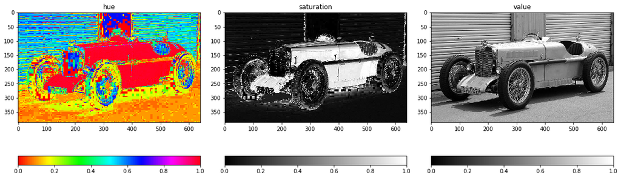

```python
hsv_data = colors.rgb_to_hsv(rgb_data)print("hsv_data.shape:", hsv_data.shape)hsv_data2 = np.moveaxis(hsv_data, -1, 0)print("hsv_data2.shape:", hsv_data2.shape)f, (ax1, ax2, ax3) = plt.subplots(1, 3, figsize=(16,6))plot1 = ax1.imshow(hsv_data2[0], cmap='hsv', vmin=0, vmax=1)f.colorbar(plot1, ax=ax1, orientation='horizontal')_ = ax1.set_title("hue")plot2 = ax2.imshow(hsv_data2[1], cmap='gray', vmin=0, vmax=1)f.colorbar(plot2, ax=ax2, orientation='horizontal')_ = ax2.set_title("saturation")plot3 = ax3.imshow(hsv_data2[2], cmap='gray', vmin=0, vmax=1)f.colorbar(plot3, ax=ax3, orientation='horizontal')_ = ax3.set_title("value")f.tight_layout()
```

Thinking about another way to convert color image to grayscale. In this function, L value is calculate using this formula: L = R * 0.2125 + G * 0.7154 + B * 0.0721. This method is called ITU-R BT.709 luma transform. We implemented this method since ITU-R 601-2 is used in the [Pillow.Image.convert](https://pillow.readthedocs.io/en/stable/reference/Image.html#PIL.Image.Image.convert). Also, ITU-R 601-2 has been used for old televisions.

This formula reflects the fact that the human eye is more sensitive to certain wavelengths of light than others, which affects the perceived brightness of a color. Blue light appears least bright, green appears brightest, and red is somewhere in between.

https://www.telestream.net/pdfs/whitepapers/wp-Different-Color-Spaces-QC.pdf

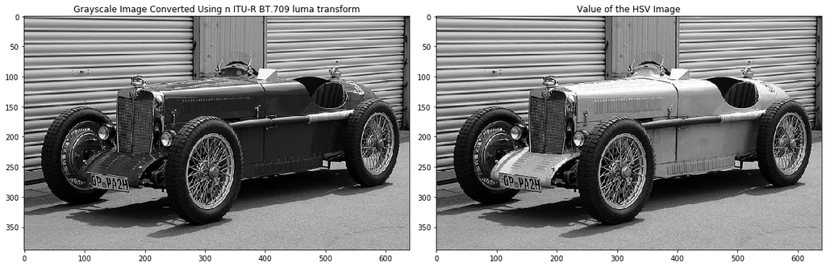

```python
rgb_img = plt.imread("Data/oldtimer.png")# ITU-R BT.709 is used for newer high-definition televisionsgray_scale_img = rgb_img[:,:,0] * 0.2125 + rgb_img[:,:,1] * 0.7154 + rgb_img[:,:,2] * 0.0721# ITU-R 601-2 is used for old analog televisions#gray_scale_img = rgb_img[:,:,0] * 299/1000 + rgb_img[:,:,1] * 587/1000 + rgb_img[:,:,2] * 114/1000 f, (ax1, ax2) = plt.subplots(1, 2, figsize=(16,12))ax1.imshow(gray_scale_img, cmap="gray", vmin=0, vmax=1)ax1.set_title("Grayscale Image Converted Using n ITU-R BT.709 luma transform")ax2.imshow(hsv_data2[2], cmap='gray', vmin=0, vmax=1)ax2.set_title("Value of the HSV Image")f.tight_layout()
```

Outputting a version of the image in which saturation has been reduced by 50%.

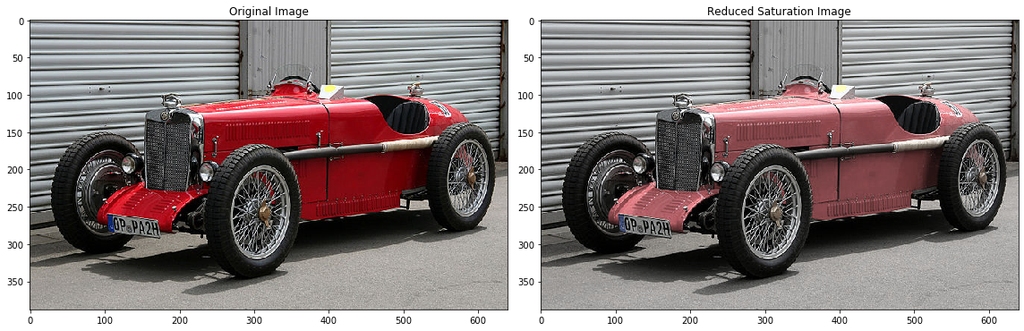

```python
modified_hsv = hsv_data.copy()modified_hsv[:,:,1] *= 0.5reduced_saturation_img = colors.hsv_to_rgb(modified_hsv)f, (ax1, ax2) = plt.subplots(1, 2, figsize=(16,12))_ = ax1.imshow(rgb_data)_ = ax1.set_title("Original Image")_ = plt.imshow(reduced_saturation_img)_ = ax2.set_title("Reduced Saturation Image")f.tight_layout()
```

Creating a simple “aged photograph” effect by globally blending the half-desaturated image from the previous step with some amount of brown.

Car image has been blended with brown color and a brown colorized old photo texture.

```python
# source: https://www.photoshopsupply.com/patterns-textures/free-dust-textures# license: https://www.photoshopsupply.com/license# This file is free for Personal and Commercial use with attribution.!wget https://www.photoshopsupply.com/wp-content/uploads/2019/07/film-texture-1.jpg -O film-texture-1.jpg
```

[output not shown]

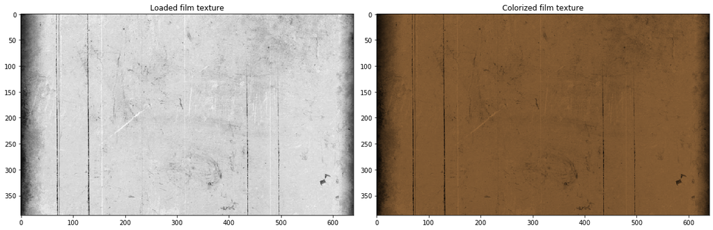

```python
f, (ax1, ax2) = plt.subplots(1, 2, figsize=(16,12))# Load film texturefilm_texture = Image.open("film-texture-1.jpg")film_texture = film_texture.resize((rgb_data.shape[1], rgb_data.shape[0])) # resize the image as same as the car imagefilm_texture = np.array(film_texture)/255.0 # normalize between 0 and 1# brown hsv code: https://en.wikipedia.org/wiki/Brownfilm_texture_hsv = colors.rgb_to_hsv(film_texture)film_texture_hsv[:,:,0] = 30/360film_texture_hsv[:,:,1] = 0.6  # saturation is modified!film_texture_hsv[:,:,2] *= 0.59film_texture_colorized = colors.hsv_to_rgb(film_texture_hsv)_=plt.imshow(film_texture_colorized)ax1.imshow(film_texture)ax1.set_title("Loaded film texture")ax2.imshow(film_texture_colorized)ax2.set_title("Colorized film texture")f.tight_layout()
```

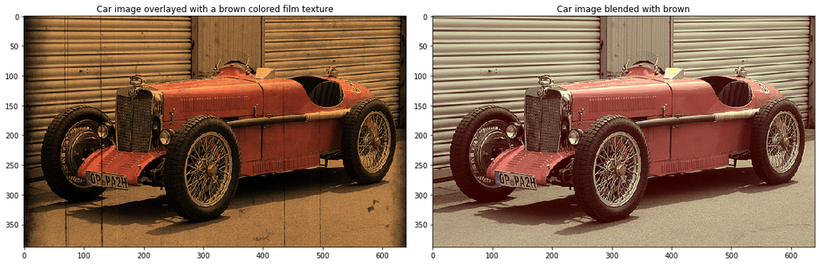

```python
# https://en.wikipedia.org/wiki/Blend_modes#Overlay# a is base layer, b is top layerdef overlay(a,b):    mask = a < 0.5    c = a.copy()    c[mask] = 2 * a[mask] * b[mask]    c[~mask] = 1 - 2*(1-a[~mask]) * (1-b[~mask])    return c# Create only brown imagebrown_hsv = film_texture_hsv.copy()brown_hsv[:,:,0] = 30/360brown_hsv[:,:,1] = 0.3  # saturation is modified!brown_hsv[:,:,2] = 0.59brown_rgb = colors.hsv_to_rgb(brown_hsv)f, (ax1, ax2) = plt.subplots(1, 2, figsize=(16,12))new_image1 = overlay(film_texture_colorized, reduced_saturation_img)ax1.imshow(new_image1)ax1.set_title("Car image overlayed with a brown colored film texture")new_image2 = overlay(brown_rgb, reduced_saturation_img)ax2.imshow(new_image2)ax2.set_title("Car image blended with brown")f.tight_layout()
```

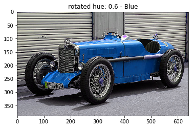

```python
rotate_for_blue = 0.6img = colors.rgb_to_hsv(rgb_data)modified_hsv = img.copy()modified_hsv[:,:,0] += rotate_for_bluemodified_hsv[:,:,0] %= 1.0new_rgb_image = colors.hsv_to_rgb(modified_hsv)plt.imshow(new_rgb_image)_ = plt.title("rotated hue: " + str(rotate_for_blue) + " - Blue")
```

```python
from matplotlib.animation import FuncAnimationfrom IPython.display import HTMLfig, ax = plt.subplots(figsize=(9,6))def update(frame):    img = colors.rgb_to_hsv(rgb_data)    modified_hsv = img.copy()    modified_hsv[:,:,0] += frame    modified_hsv[:,:,0] = modified_hsv[:,:,0] % 1.0    new_rgb_image = colors.hsv_to_rgb(modified_hsv)    plt.imshow(new_rgb_image)    plt.title("rotated hue: " + str(round(frame,2)))ani = FuncAnimation(fig, update, frames=np.linspace(0, 1, 40), blit=False)video = ani.to_html5_video()plt.close()HTML(video)
```

[video not shown]

Manipulating the hue values of only those pixels which show a pinkish / purplelish hue such that their hue becomes yellowish. (In plainer Englisher: implement code that makes the flow yellow.)

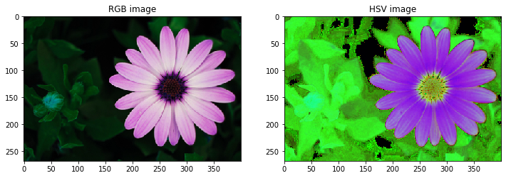

```python
img = cv2.imread("Data/colored_flower.png")hsv_img = cv2.cvtColor(img, cv2.COLOR_BGR2HSV)fig, (ax1, ax2) = plt.subplots(1, 2, figsize=(12,12))_ = ax1.imshow(img); _ = ax1.set_title("RGB image")_ = ax2.imshow(hsv_img); _ = ax2.set_title("HSV image")
```

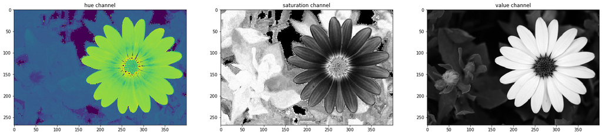

```python
#hsv_img = np.array(hsv_img)h = hsv_img[:,:,0]s = hsv_img[:,:,1]v = hsv_img[:,:,2]#_ = plt.imshow(img); _ = plt.title("original image")fig, (ax1, ax2, ax3) = plt.subplots(1, 3, figsize=(25,25))_ = ax1.imshow(h); _ = ax1.set_title("hue channel")_ = ax2.imshow(s, cmap="gray"); _ = ax2.set_title("saturation channel")_ = ax3.imshow(v, cmap="gray"); _ = ax3.set_title("value channel")
```

The hue range of reddish/pinkish/purplish color is [240,360]. In this flower image, the flower is more pinkish, and considering the hue ranges of colors, shifting 120 degrees the hue values of pinkish parts of the image will make the flower look yellowish. Since the hue range of OpenCV ranges between [0,180], the hue range of reddish/pinkish/purplish color is approximately [120,180] and 60 degrees shifting can be applied to obtain yellowish color.  
The following two cells show the ways of shifting the color of the flower. The former cell uses a mask while the latter employs np.where method.

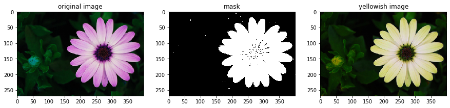

```python
mask = h>120modified_hsv_img = hsv_img.copy()modified_hsv_img[:,:,0][mask] = hsv_img[:,:,0][mask] + 60modified_img = cv2.cvtColor(modified_hsv_img, cv2.COLOR_HSV2RGB)fig, (ax1, ax2, ax3) = plt.subplots(1,3,figsize=(15,15))_ = ax1.imshow(img); _ = ax1.set_title("original image")_ = ax2.imshow(mask, cmap="gray"); _ = ax2.set_title("mask")_ = ax3.imshow(modified_img); _ = ax3.set_title("yellowish image")
```

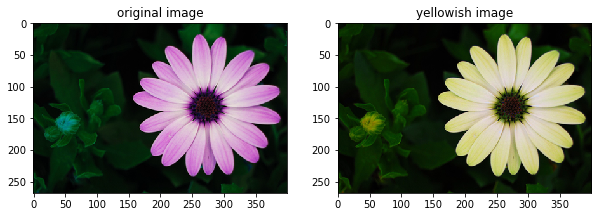

```python
yellowish_hue = np.where(h>120, (h+60)%180, h)modified_hsv_img = hsv_img.copy()modified_hsv_img[:,:,0] = yellowish_huemodified_img = cv2.cvtColor(modified_hsv_img, cv2.COLOR_HSV2RGB)fig, (ax1, ax2) = plt.subplots(1,2,figsize=(10,10))_ = ax1.imshow(img); _ = ax1.set_title("original image")_ = ax2.imshow(modified_img); _ = ax2.set_title("yellowish image")
```

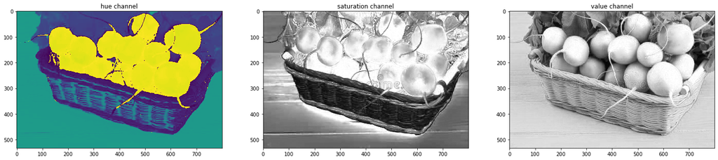

[figure not shown]

```python
img = cv2.imread("Data/reddish_img.jpg")   #opencv uses BGR color as a default color space to display imageshsv_img = cv2.cvtColor(img, cv2.COLOR_BGR2HSV)img = cv2.cvtColor(img, cv2.COLOR_BGR2RGB)h = hsv_img[:,:,0]s = hsv_img[:,:,1]v = hsv_img[:,:,2]fig, (ax1, ax2, ax3) = plt.subplots(1, 3, figsize=(25,25))_ = ax1.imshow(h); _ = ax1.set_title("hue channel")_ = ax2.imshow(s, cmap="gray"); _ = ax2.set_title("saturation channel")_ = ax3.imshow(v, cmap="gray"); _ = ax3.set_title("value channel")mask = ((h>165) | (h<5)) & (s>80) & (v>80)  # Red color parametersmask = mask.astype(np.uint8)*255fig, (ax1, ax2) = plt.subplots(1, 2, figsize=(12,12))_ = ax1.imshow(img); _ = ax1.set_title("original image")_ = ax2.imshow(mask, cmap="gray"); _ = ax2.set_title("mask")
```